# Introduction to RMarkdown

## Chunk options

The way chunks are evaluated and displayed can be changed with various options

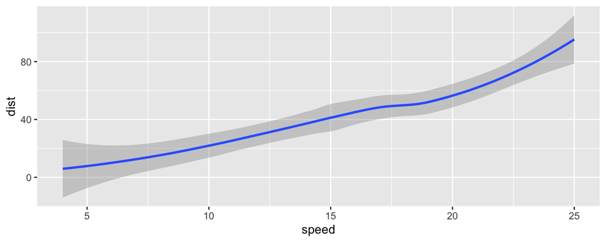

````markdown
```{r , message=FALSE, echo=FALSE, fig.height=3}
library(ggplot2)
ggplot(cars) + geom_smooth(aes(x=speed,y=dist))
```
````

## The RMarkdown engine

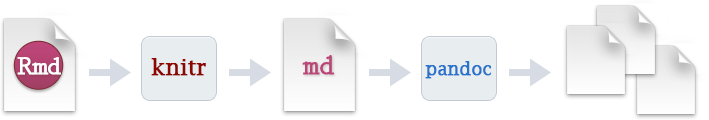

The engine behind RMarkdown is an R package called `knitr` and a command line program called `pandoc`

- `knitr` does the job of running code in chunks and generating an intermediate Markdown file
- `pandoc` converts the Markdown file into other formats such as html or pdf.
- `RStudio` automates this process

## Supported Languages

RMarkdown is not just for R.

```r
names(knitr::knit_engines$get())
```

```
##  [1] "awk"       "bash"      "coffee"    "gawk"      "groovy"
##  [6] "haskell"   "lein"      "mysql"     "node"      "octave"
## [11] "perl"      "psql"      "Rscript"   "ruby"      "sas"
## [16] "scala"     "sed"       "sh"        "stata"     "zsh"
## [21] "highlight" "Rcpp"      "tikz"      "dot"       "c"
## [26] "fortran"   "fortran95" "asy"       "cat"       "asis"
## [31] "stan"      "block"     "block2"    "js"        "css"
## [36] "sql"       "go"        "python"    "julia"     "sass"
## [41] "scss"
```

## —

For example here is a code block that runs `bash`

```bash
echo "Hello from bash" | cowsay
```

```
##  _________________
## < Hello from bash >
##  -----------------
##         \   ^__^
##          \  (oo)\_______
##             (__)\       )\/\
##                 ||----w |
##                 ||     ||
```

## —

If you want to use `python` just install the `reticulate` package

```python
print("Tabs or spaces I don't care, just don't mix them anywhere")
```

```
## Tabs or spaces I don't care, just don't mix them anywhere
```

RStudio even works nicely with python graphics engines like `matplotlib` if you’re into that sort of thing.

## RMarkdown for reproducible research

## My workflow

My research tasks are divided evenly between running command-line tools on the HPC and analyzing outputs from those tools with R.

I document my command-line workflows with plain `Markdown` and `bash` scripts I do all my `R` work with `RMarkdown` so it is easily converted into documentation

[figure not shown]

## An Example

[figure not shown]

## Github Output

I often use the output format `github_document`. This works very well for publication because the rendered markdown files will be turned into nice web pages by Github.

```markdown
---
title: "Population Structure"
author: "Ira Cooke"
output: github_document
---
```

## Other types of output

At the top of every RMarkdown document is a short bit of `yaml`. Here you can change the output type.

RMarkdown can be rendered into many different output types including

- Presentations (`ioslides_presentation`, `beamer_presentation`)
- Document formats (`pdf_document`, `word_document`, `latex_document`)
- Markdown derivatives (`github_document`, `md_document`)
- html (`html_document`)

In principle it is easy to switch output types but you will often need to customize to get things looking good in different formats.

## Learning Resources

**Start with:**

- The RMarkdown section of the book `r4ds` https://r4ds.had.co.nz/r-markdown.html

**Refer to these to lookup features:**

- A book by the creators of RMarkdown [R Markdown: The Definitive Guide](https://bookdown.org/yihui/rmarkdown/)
- RStudio Cheat Sheets https://rmarkdown.rstudio.com/lesson-15.html

**To find out fancy things RMarkdown can do:**

- RStudio’s guide to RMarkdown https://rmarkdown.rstudio.com/